# Time_Series_Regression_II

**IMPORTANT**: since the response $y$ is transformed using the $log$ function, **the coefficients need to be interpreted as semi-elasticities**. The proper way to do this is explained in **reference 2** as well as on a **dedicated video on blackboard covering elasticities**.

- Exercise 2 of this notebook consists in given the interpretation of these coefficients. A detailed solution will be provided in due curse.

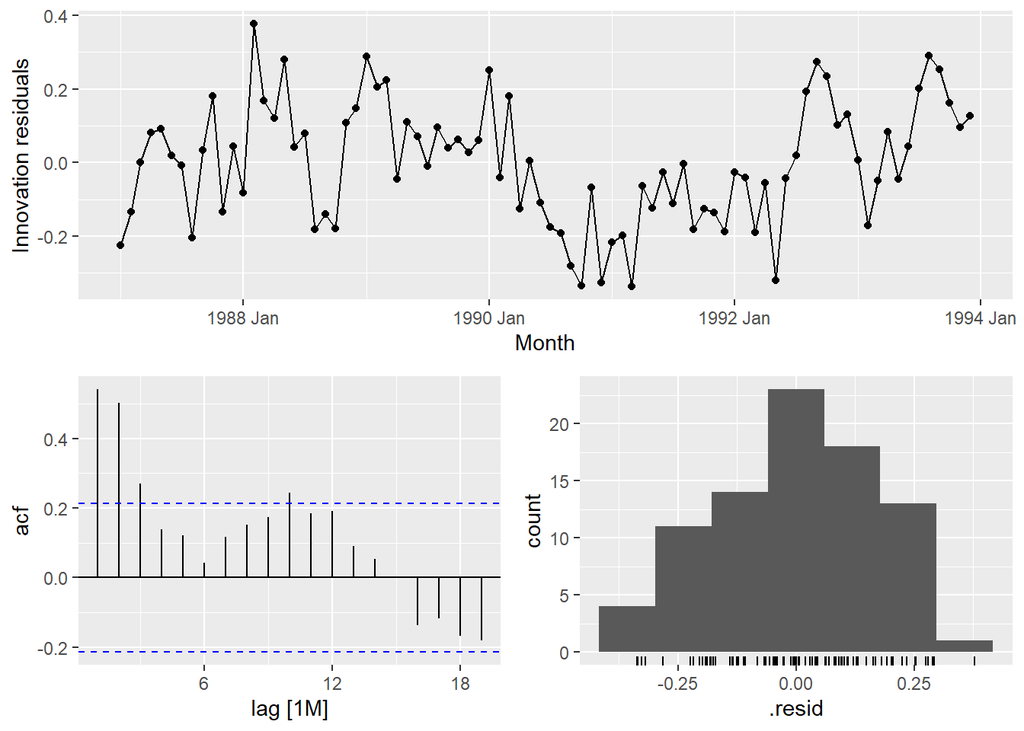

```r
fit %>% gg_tsresiduals()
```

Looking at the residuals, we see that they are autocorrelated. Specifically their slow decay reveals some non-linearity in the trend that has not been accurately captured by the model and has bled down to the residuals.

```r
augment(fit) %>%
  features(.innov, ljung_box, dof = 14, lag = 24)
```

```
# A tibble: 1 x 3
  .model lb_stat lb_pvalue
  <chr>    <dbl>     <dbl>
1 reg       112.         0
```

The timeplot of the residual appears to reveal some heteroskedasticity, which can be more clearly visualized using box-plots that group the values by month (not necessary, introduced as additional technique):

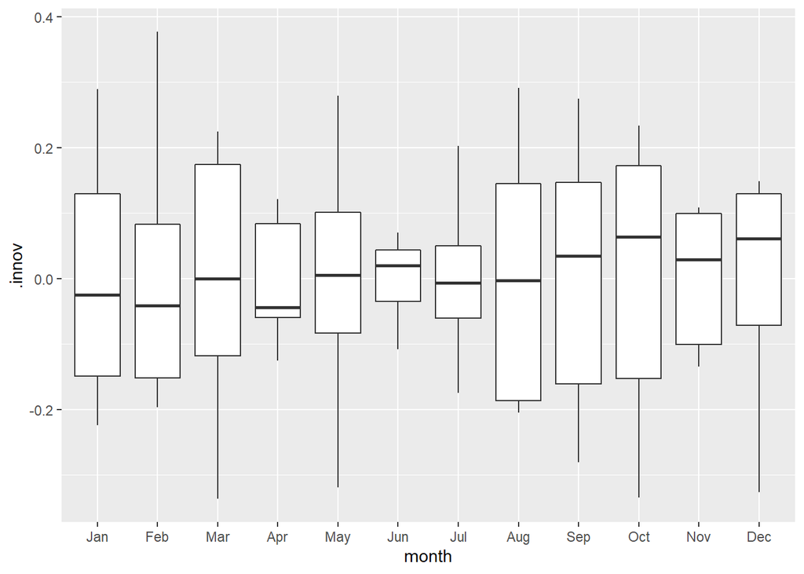

```r
augment(fit) %>%
  mutate(month = month(Month, label = TRUE)) %>%
  ggplot(aes(x = month, y = .innov)) +
  geom_boxplot()
```

This reveals some potential heteroskedasticity of the residuals over time that may render the prediction intervals inaccurate.

The model could be improved by taking into account the non-linearity in the trend. Remember nonetheless that this is risky, because extrapolating non-linear trends can quickly lead to inaccurate forecasts. A piece-wise linear trend could be a better alternative to improve the fit of the model.

Including auto-regressive terms could help as well with the autocorrelation of the residuals. For this, see the next chapter on ARIMA models.

Regardless of these considerations, let us perform some forecasts to visualize the predictions given by such model.

To do this, **we need to specify new values for the regressors that we defined manually**. In this case **the variable created manually is the dummy associated to the festival**. Without these values the model is not able to generate forecasts:

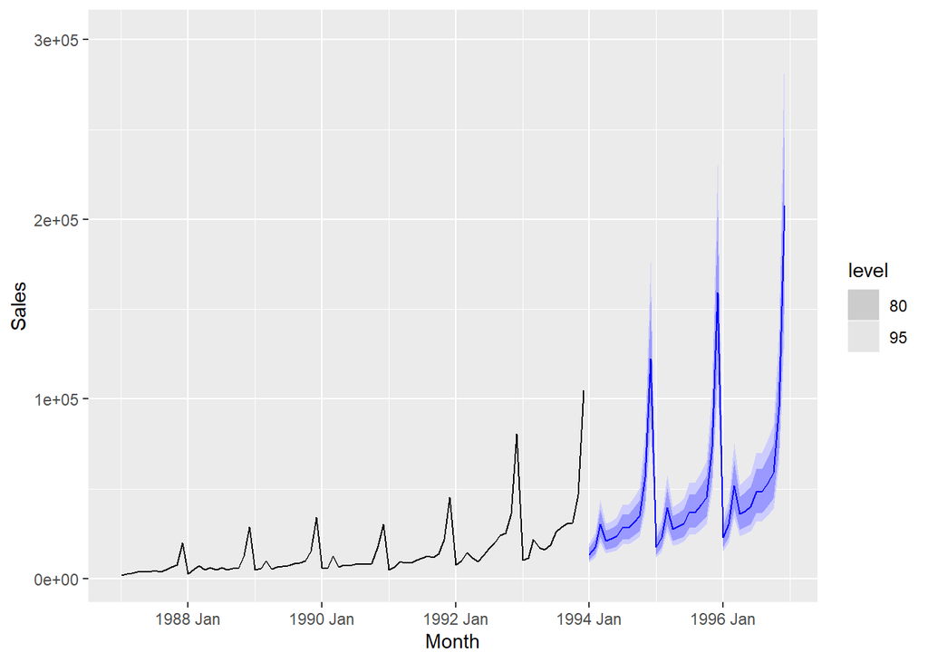

```r
future_souvenirs <- new_data(souvenirs_dummy, n = 36) %>%
  mutate(dummy_fest = month(Month) == 3)

fit %>%
  forecast(new_data = future_souvenirs) %>%
  autoplot(souvenirs_dummy)
```

```r
fit %>% report()
```

```
Series: Sales
Model: TSLM
Transformation: log(Sales)

Residuals:
      Min        1Q    Median        3Q       Max
-0.336727 -0.127571  0.002568  0.109106  0.376714

Coefficients:
                Estimate Std. Error t value Pr(>|t|)
(Intercept)    7.6196670  0.0742471 102.626  < 2e-16 ***
trend()        0.0220198  0.0008268  26.634  < 2e-16 ***
season()year2  0.2514168  0.0956790   2.628 0.010555 *
season()year3  0.2660828  0.1934044   1.376 0.173275
season()year4  0.3840535  0.0957075   4.013 0.000148 ***
season()year5  0.4094870  0.0957325   4.277 5.88e-05 ***
season()year6  0.4488283  0.0957647   4.687 1.33e-05 ***
season()year7  0.6104545  0.0958039   6.372 1.71e-08 ***
season()year8  0.5879644  0.0958503   6.134 4.53e-08 ***
season()year9  0.6693299  0.0959037   6.979 1.36e-09 ***
season()year10 0.7473919  0.0959643   7.788 4.48e-11 ***
season()year11 1.2067479  0.0960319  12.566  < 2e-16 ***
season()year12 1.9622412  0.0961066  20.417  < 2e-16 ***
dummy_festTRUE 0.5015151  0.1964273   2.553 0.012856 *
---
Signif. codes:  0 '***' 0.001 '**' 0.01 '*' 0.05 '.' 0.1 ' ' 1

Residual standard error: 0.179 on 70 degrees of freedom
Multiple R-squared: 0.9567, Adjusted R-squared: 0.9487
F-statistic:   119 on 13 and 70 DF, p-value: < 2.22e-16
```

## Trading days

Sales data can be affected by the number of tranining days in a month. The **number of trading days in each month can be used as a predictor to account for this.**

Alternatively 7 variables can be created, each including the number of different days of the week as a predictor.

## Lagged values of the predictor variables

The effect of a predictor can have an impact lasting beyond the point in time where it occurs. For example, advertising expenditure can have an effect beyond their actual campaign on the sales.

To account for that, lagged valued of those predictors can be included. For example:

$$\begin{align*}
x_{1} &= \text{advertising for previous month;} \\
x_{2} &= \text{advertising for two months previously;} \\
& \vdots \\
x_{m} &= \text{advertising for $m$ months previously.}
\end{align*}$$

It is usual that the coefficients are required to reduce as the lag increases.

## Easter

Easter is preculiar because the exact date when it occurs changes from year to year. Also, its effect can last for several days.

A dummy variable can be used with value one where the holiday falls in the particular time period and zero otherwise.

With monthly data, if Easter starts in March and ends in April the dummy variable is split proportionally between both months.

# Non-linear functional forms

## Linearity in the parameters

In many cases a non-linear functional form might be more suitable for our data. We may include non-linear functions as regressors as long as we preserve the linearity in the parameters required by linear regression. Linearity in the parameters means that:

- **each additive term in the model contains only one parameter**.
- **only as a multiplicative constant on the independent variable**.

Examples of models that would violate the requirement of linearity in the parameters are:

$$\begin{align*}
y = \beta_0 + \beta_1\beta_2x + \varepsilon
\end{align*}$$
$$\begin{align*}
y = \beta_0 + e^{\beta_1x} +\varepsilon
\end{align*}$$

Some examples of models that introduce non-linear functional forms while respecting the linearity in the parameters are studied now. We assume only one predictor to keep things simple.

## log-log functional form

$$\begin{align*}
log(y) = \beta_0 + \beta_1log(x)+\varepsilon
\end{align*}$$

In this model the **slope** $\beta_1$ can be interpreted as an elasticity: the **average percentage change in y resulting from the percent change in x associated to a differential delta x**.

### Coefficients as elasticities

Please **watch the dedicated video where a detailed explanation of this concept in the context of regression is given**. Also, **reference 2 provides a good summary of the topic**.

An elasticity coefficient is the **ratio of percent change in the forecast variable y to the percent change in the predictor variable x**. Mathematically the elasticity is defined as:

$$\begin{align*}
\frac{\frac{dy}{y}}{\frac{dx}{x}}=\frac{y'}{y}x
\end{align*}$$

If we take conditional expectation on the left and the right parts of the equation (*given that x has occurred*):

$$\begin{align*}
E(log(y)|x) = E(\beta_0+\beta_1*log(x)+\varepsilon|x) = \beta_0 + \beta_1*log(x)
\end{align*}$$

We have used the fact that the residuals have mean 0.

Now, taking derivatives on both sides of the equation we get:

$$\begin{align*}
\frac{1}{y}\frac{dy}{dx} = \frac{\beta_1}{x} \rightarrow \beta_1 = \frac{\frac{dy}{y}}{\frac{dx}{x}} = \frac{y'}{y}x
\end{align*}$$

### Interpretation of the coefficients

In other words, the coefficient $\beta_1$ expresses the average percent increment of y per differential percent increment of x. The equation above is actually a differential equation, which means it holds for infinitesimally small dx and its associated dy.

To compute the actual percent change in y associated to a one percent change in x we need to integrate. **See reference 2** or the **associated video on blackboard** to see how to do this. **This is actually improtant material for the exam** as it is required to **give a proper interpretation of the coefficients**

## log-linear form

$$\begin{align*}
log(y) = \beta_0 + \beta_1x+\varepsilon
\end{align*}$$

### Coefficients as semi-elasticities

In this case, we obtain semi-elasticities instead of elasticities. Taking expectations to do away with the residuals and deriving both sides as before:

$$\begin{align*}
\frac{1}{y}\frac{dy}{dx} = \beta_1 \rightarrow \beta_1 = \frac{\frac{dy}{y}}{dx}
\end{align*}$$

In other words, the coefficient expresses the average percent increment in y associated to a differential $dx$.

### Interpretation of the coefficients

In other words, the coefficient expresses the average percentual increment in y per differential increment of x. The equation above is acutally a differential equation, which means it holds for infinitesimally small dx and dy.

To compute the actual percent change in y associated to a unit change in x we need to integrate. **See reference 2** or the **associated video on blackboard** to see how to do this. **This is actually improtant material for the exam** as it is required to **give a proper interpretation of the coefficients**

## linear-log form

$$\begin{align*}
y = \beta_0 + \beta_1log(x)+\varepsilon
\end{align*}$$

### Coefficients as semi-elasticities

In this case, we obtain semi-elasticities instead of elasticities. Taking expectations to do away with the residuals and deriving both sides as before:

$$\begin{align*}
\frac{dy}{dx} = \frac{\beta_1}{x} \rightarrow \beta_1 = \frac{dy}{\frac{dx}{x}}
\end{align*}$$

### Interpretation of the coefficients

In other words, the coefficient expresses the change in y per differential percent increment of x. The equation above is actually a differential equation, which means it holds for infinitesimally small $dx$ and $dy$.

To compute the actual change in $y$ associated to a one percent change in $x$ we need to integrate. **See reference 2** or the **associated video on blackboard** to see how to do this. **This is actually improtant material for the exam** as it is required to **give a proper interpretation of the coefficients**

## Reminder: $log(1+x)$

To apply the logarithmic transformation, all the variables must be greater than 0. In the case that the variable $x$ contains zeros, we could resort to the transformation $log(1+x)$

- We add one and not a different constant because in this manner **zeros in the initial scale remain zeros in the transformed scale.**. Also $log(1+x)$ may be linearized around zero with a slope of 1.

# Selecting Predictors

Usually there are *many possible predictors*. Basing the selection of variables on statistical significance is difficult:

1. Statistical significance does not always indicate predictive value (see section 7.8 of the book).
2. p-values can be misleading when two or more predictors are correlated.

Instead we will use measures of **predictive accuracy**. We will use **five such measures**, following ref [1].

## Adjusted $R^2$

See the foregoing section. As stated there, maximising $\bar{R^2}$ works well for selecting predictos, but tends to lead to too many predictors.

## Cross-validation

We can use a *leave-one-out* approach to select predictors. This procedure makes efficient use of the data and involves these steps:

1. Remove observation $t$ from the data set, and and fit the model using the remaining data. Then compute the error ($e_{t}^*=y_{t}-\hat{y}_{t}$) for the ommited observation. Note that this is an error and not a residual because this observation was not used in training the model.
2. Repeat step 1 for $t=1,\dots,T$
3. Compute the MSE from $e_{1}^*,\dots,e_{T}^*$. We will refer to this as **CV**.

Under this criterion, **the best model is the one with the smallest value of CV**. The above steps are efficiently implemented within the `glance()` function.

The figure below (ref [1]) is a depiction of the datasets necessary for the leave-one-out approach:

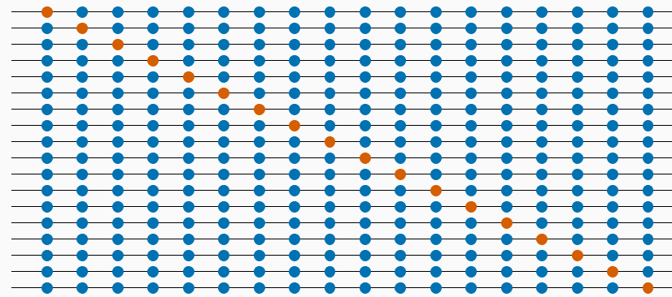

## Akaike’s Information Creterion

We now introduce a series of inormation criteria. The main idea behind these is to **penalize the fitting of the model (minimization of SSE) with the model’s complexity, accounted for via the number of parameters to be estimated**.

Akaike’s Information Crietrion is defined as:

$$\begin{align*}
\text{AIC} = T\log\left(\frac{\text{SSE}}{T}\right) + 2(k+2),
\end{align*}$$

where:

- k is the number of predictors included
- T is the number of observations.

**The model with minimum value of the AIC is often the best model for forecasting.** For large values of $T$, minimizing the AIC is equivalent to minimizing the CV value.

The AIC is developed using principles of Maximum Likelihood and negative entropy (Kullback-Liebleck divergence). The exact derivation of the AIC is somewhat beyond the scope of this course.

The student is referred to ref. 6 to delve into the exact mathematical formulation of the model.

## Corrected Akaike’s Information Criterion

If $T$ is small, the AIC tends to select too many predictors. The bias-corrected version of the AIC was developed for these smaller samples:

$$\begin{align*}
\text{AIC}_{\text{c}} = \text{AIC} + \frac{2(k+2)(k+3)}{T-k-3}.
\end{align*}$$

As with the $AIC$, the $AICc$ shall be minimized.

## Schwarz’s Bayesian Information Criterion

Alternatively named as $BIC$, $SBIC$ or $SC$

$$\begin{align*}
\text{BIC} = T\log\left(\frac{\text{SSE}}{T}\right) + (k+2)\log(T)
\end{align*}$$

- The goal again is to minimize BIC.
- BIC penalizes the complexity (number of parameters) more than AIC.
- BIC is asymptotically minimized at the model order having the highest posterior probability. This involves delving into bayesian statistics, which is outside the scope of the course. Again, the reader is referred to reference 6 to further read about the topic.

## Recommended measures

We will use either $AICc$, $AIC$ or $CV$ statistics for model selection, since our goal is to find the best model for forecasting. **If T is large enough, they will all lead to the same model**.

## Example: US consumption

We re-take the case of US-consumption using Income, Production, Savings and Unemployment as predictors.

A predictor can either be included or not, therefore, the number of possible models with four regressors is $2^4=16$ models. The table below shows the selection metrics for each of the 16 models:

| Income | Production | Savings | Unemployment | AdjR2 | CV | AIC | AICc | BIC |
| --- | --- | --- | --- | --- | --- | --- | --- | --- |
| X | X | X | X | 0.763 | 0.104 | -456.6 | -456.1 | -436.9 |
| X | X | X |  | 0.761 | 0.105 | -455.2 | -454.9 | -438.7 |
| X |  | X | X | 0.760 | 0.104 | -454.4 | -454.1 | -437.9 |
| X |  | X |  | 0.735 | 0.114 | -435.7 | -435.5 | -422.6 |
| X | X |  | X | 0.366 | 0.271 | -262.3 | -262.0 | -245.8 |
|  | X | X | X | 0.349 | 0.279 | -257.1 | -256.8 | -240.7 |
| X |  |  | X | 0.345 | 0.276 | -256.9 | -256.6 | -243.7 |
| X | X |  |  | 0.336 | 0.282 | -254.2 | -254.0 | -241.0 |
|  | X | X |  | 0.324 | 0.287 | -250.7 | -250.5 | -237.5 |
|  |  | X | X | 0.311 | 0.291 | -246.9 | -246.7 | -233.7 |
|  | X |  | X | 0.308 | 0.293 | -246.1 | -245.9 | -232.9 |
|  | X |  |  | 0.276 | 0.304 | -238.1 | -238.0 | -228.2 |
|  |  |  | X | 0.274 | 0.303 | -237.4 | -237.3 | -227.5 |
| X |  |  |  | 0.143 | 0.356 | -204.6 | -204.5 | -194.7 |
|  |  | X |  | 0.061 | 0.388 | -186.5 | -186.4 | -176.7 |
|  |  |  |  | 0.000 | 0.409 | -175.1 | -175.0 | -168.5 |

The table has been arranged by AIC:

- In this case, the best model contains all four predictors
- The first four models clearly outperform the rest. This indicates that `savings` and `income` are much more relevant than the rest of the variables.
- The first three rows have almost identical values, so we could possibly drop `Production` or `Unemployment` and get similar forecasts. This is because `Production` and `Unemployment` are highly negatively correlated, so most of the predictive information is contained already in one of these variables.

## Best Subset Regression

If possible, all potential models should be fitted and the best model should be selected. This is known as “best subsets” or “all possible subsets” regression.

## Stepwise regression

The number of potential models grows as two to the power of the number of predictors ($2^n$). Consequently, at some point it might be unfeasible to fit all the models. In this case **stepwise regression** makes more sense.

**Stepwise regression is not guaranteed to lead to the best possible model**, but it usually leads to a model that is good enough for forecasting.

### Bakcwards stepwise regression

1. Start with a model fitting all predictors
2. Remove one predictor at a time. Keep the model if it improves the measure of predictive accuracy.
3. Iterate until no further improvement

### Forward stepwise regression

1. Start with a model fitting only an intercept
2. Add one predictor at a time and keep the **one that improves the measure of predictive accuracy most**.
3. Repeat until no further improvement can be achieved.